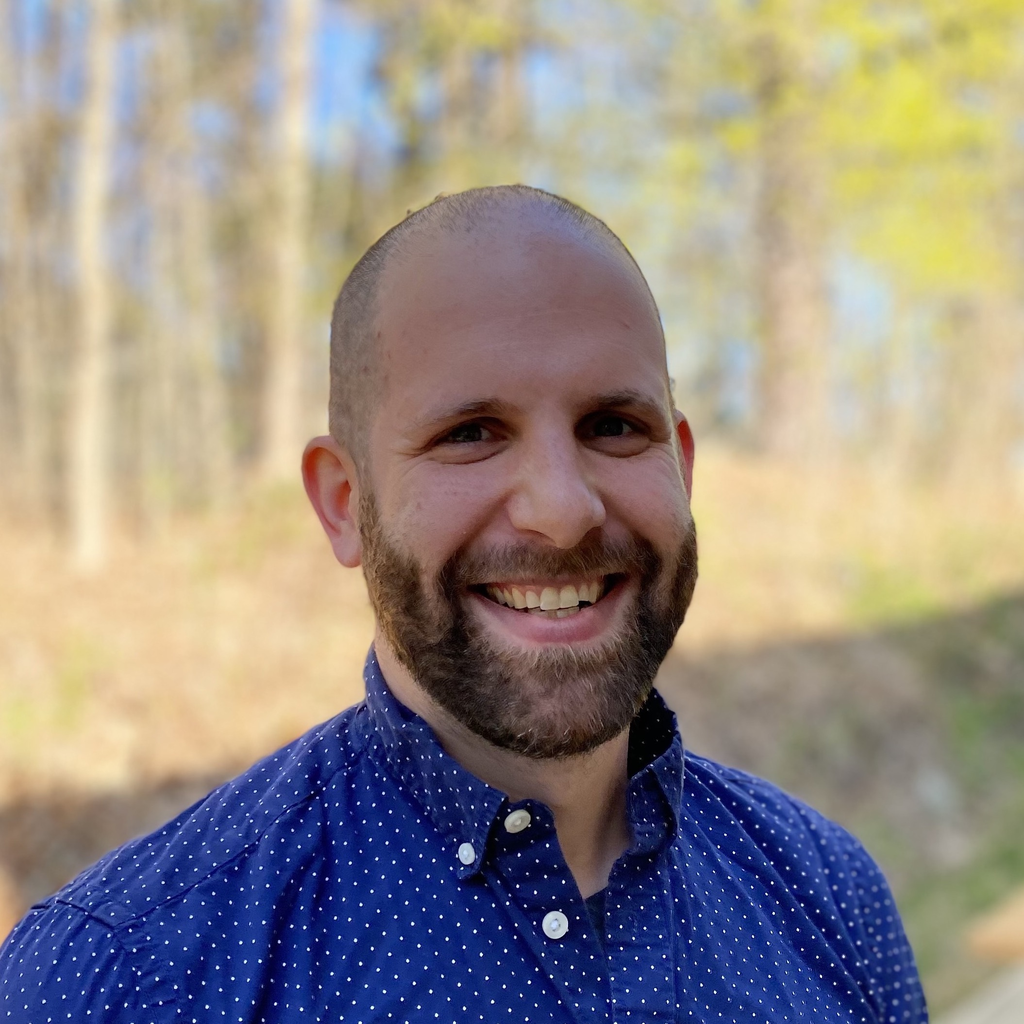

# Samuel E. Marsh

## Full Publication Bibliography

#### Primary Research

Barr HJ, Caldwell SK, Reimertz JM, Depp CM, Walker AJ, **Marsh SE**, Gupte AS, Hingerl M, Park S, Patel J, Park S-O, Ferraro S, Lipton J, Stevens B (2025). The circadian clock regulates scavenging of fluid-borne substrates by brain border-associated macrophages. *bioRxiv*.

[figure not shown]

[Full Text](https://doi.org/10.64898/2025.12.08.693074) | [PDF Full Text](https://www.biorxiv.org/content/10.64898/2025.12.08.693074v1.full.pdf) |

Barr HJ, Depp C, Hingerl M, Nguyen T, Reimertz JM, Connolly E, Patel J, Doman JL, **Marsh SE**, Stevens B (2025). Conserved phenotype and function of human brain border-associated macrophages in iPSC-derived models. *bioRxiv*.

[figure not shown]

[Full Text](https://doi.org/10.64898/2025.12.11.693582) | [PDF Full Text](https://www.biorxiv.org/content/10.64898/2025.12.11.693582v1.full.pdf) |

Walker AJ, Fisher TM, Caldwell SK, Gupte AS, Reimertz J, Sabikunnahar B, **Marsh SE**, de Soysa Y, Gazestani V, Walker AC, Huang Y, Mavinkurve A, Barr HJ, Lanser TB, Murphy S, Bowling S, Dissing-OIesen L, Camargo FD, Stevens B (2025). Early life stromal niches orchestrate local B lymphopoiesis at the brain’s borders. *bioRxiv*.

[figure not shown]

[Full Text](https://doi.org/10.1101/2025.11.27.690844) | [PDF Full Text](https://www.biorxiv.org/content/10.1101/2025.11.27.690844v1.full.pdf) | [Data Link](https://www.ncbi.nlm.nih.gov/geo/query/acc.cgi?acc=GSE312965) |

Gazestani V, Kamath T, Nadaf NM, Dougalis A, Burris SJ, Rooney B, Junkkari A, Vanderburg C, Pelkonen A, Gomez-Budia M, Välimäki NN, Rauramaa T, Therrien M, Koivisto AM, Tegtmeyer M, Herukka SK, Abdulraouf A, **Marsh SE**, Hiltunen M, Nehme R, Malm T, Stevens B, Leinonen V, Macosko EZ (2023). Early Alzheimer’s disease pathology in human cortex involves transient cell states. *Cell*, 186(20):4438–4453.e23. PMID: 37774681. doi.org/10.1016/j.cell.2023.08.005.  
[Journal Link](https://doi.org/10.1016/j.cell.2023.08.005) |

[figure not shown]

[PDF Full Text](https://samuel-marsh.science/PDFs/Gazestani_et_al_2023.pdf) | SI Tables | [Data Link](https://braincelldata.org/resource) | [Code](https://app.terra.bio/#workspaces/fbrihuman/sconline_integrative_analysis) | [PubMed](https://pubmed.ncbi.nlm.nih.gov/37774681/)

Dolan M-J, Therrien M, Jereb S, Kamath T, Gazestani V, Atkeson T, **Marsh SE**, Goeva A, Lojek NM, Murphy S, White CM, Joung J, Liu B, Limone F, Eggan K, Hacohen N, Bernstein BE, Glass CK, Leinonen V, Blurton-Jones M, Zhang F, Epstein CB, Macosko EZ, Stevens B (2023). Exposure of iPSC-derived human microglia to brain substrates enables generation and manipulation of diverse transcriptional states in vitro. *Nature Immunology* 24(8):1382–1390. PMID: 37500887. doi.org/10.1038/s41590-023-01558-2.

[figure not shown]

[Journal Link](https://doi.org/10.1038/s41590-023-01558-2) |

[figure not shown]

[PDF Full Text](https://www.nature.com/articles/s41590-023-01558-2.pdf) | [SI Tables](https://www.nature.com/articles/s41590-023-01558-2#Sec43) | [Data Link](https://www.nature.com/articles/s41590-023-01558-2#data-availability) | [Pubmed](https://pubmed.ncbi.nlm.nih.gov/37500887/)

💥**Marsh SE**, Walker, AJ, Kamath, T, Dissing-Olesen, L, Hammond, TR, de Soysa, TY, Young, AMH, Murphy, S, Abdulraouf, A, Nadaf, N, Dufort, C, Walker, AC, Lucca, LE, Kozareva, V, Vanderburg, C, Hong, S, Bulstrode, H, Hutchinson, PJ, Gaffney, DJ, Hafler, DA, Franklin, RJM, Macosko, EZ, Stevens, B (2022). Dissection of artifactual and confounding glial signatures by single-cell sequencing of mouse and human brain. *Nature Neuroscience* 25(3), 306-316.

[figure not shown]

[Full Text](https://doi.org/10.1038/s41593-022-01022-8) | [PDF Full Text](https://www.nature.com/articles/s41593-022-01022-8.pdf) | [PDF SI Figures & Notes/Discussion](https://static-content.springer.com/esm/art%3A10.1038%2Fs41593-022-01022-8/MediaObjects/41593_2022_1022_MOESM1_ESM.pdf) |  
[Code](https://github.com/samuel-marsh/Marsh_et-al_2022_scRNAseq_Dissociation_Artifacts) | [PubMed](https://pubmed.ncbi.nlm.nih.gov/35260865/) |

Quershi YH, Berman DE, **Marsh SE**, Klein RL, Patel VM, Simoes S, Kannan S, Petsko GA, Stevens B, Small SA (2022). The neuronal retromer can regulate both neuronal and Microglial phenotypes of Alzheimer’s disease. *Cell Reports* 38(3) 110262.

[figure not shown]

[Full Text](https://doi.org/10.1016/j.celrep.2021.110262) | PDF Full Text & SI Info | [PubMed](https://pubmed.ncbi.nlm.nih.gov/35045281/)

Shukla AK, McIntyre LL, **Marsh SE**, Schneider CA, Hoover EM, Walsh CT, Lodoen MB, Blurton-Jones M, Inlay MA (2019). CD11a expression distinguishes infiltrating myeloid cells from plaque-associated microglia in Alzheimer’s disease. *Glia* 67(5): 844-856.  
[Journal Link](https://doi.org/10.1002/glia.23575) |

[figure not shown]

[PDF Full Text](https://samuel-marsh.science/PDFs/Shukla_et_al_2019.pdf) | [DOCX SI Info](https://onlinelibrary.wiley.com/action/downloadSupplement?doi=10.1002%2Fglia.23575&file=glia23575-sup-0001-Supinfo.docx) | [PubMed](https://pubmed.ncbi.nlm.nih.gov/30588668/)

Hammond TR, Dufort C, Dissing-Olesen L, Giera S, Young A, Wysoker A, Walker AJ, Gergits F, Segel M, Nemesh J, **Marsh SE**, Saunders A, Macosko E, Ginhoux F, Chen J, Franklin RJM, Piao X, McCarroll SA, and Stevens B (2019). Single-Cell RNA Sequencing of Microglia throughout the Mouse Lifespan and in the Injured Brain Reveals Complex Cell-State Changes. *Immunity* 50(1): 253-271.e6.

[figure not shown]

[Full Text](https://doi.org/10.1016/j.immuni.2018.11.004) | PDF Full Text & SI Info | [Processed Data Link](https://github.com/samuel-marsh/Hammond-et-al_2019_Microglia_scRNAseq) | [PubMed](https://pubmed.ncbi.nlm.nih.gov/30471926/)

Mathur V, Burai R, Vest RT, Bonanno LN, Lehallier B, Zardeneta M, Mistry KN, Do D, **Marsh SE**, Abud EM, Blurton-Jones M, Li L, Lashuel HA, Wyss-Coray T (2017). Activation of the STING-dependent type I interferon response reduces microglial reactivity and neuroinflammation. *Neuron* 96(6): 1290-1302.

[figure not shown]

[Full Text](https://doi.org/10.1016/j.neuron.2017.11.032) | PDF Full Text & SI Info | [PubMed](https://pubmed.ncbi.nlm.nih.gov/29268096/)

Abud EM, Ramirez R, Martinez E, Healy L, Nguyen C, Newman S, Yeromin A, Scarfone V, **Marsh SE**, Fimbres C, Caraway C, Fote G, Mandany A, Agrawal A, Kayed R, Ghylys K, Cahalan M, Cummings B, Antel J, Mortazavi A, Carson M, Poon W, Blurton-Jones M (2017). iPSC-derived human microglia-like cells to study neurological diseases. *Neuron* 94(2): 278-293.

[figure not shown]

[Full Text](https://doi.org/10.1016/j.neuron.2017.03.042) | PDF Full Text & SI Info | [PubMed](https://pubmed.ncbi.nlm.nih.gov/28426964/)

Goldberg NRS, **Marsh SE**, Ochaba J, Shelley BC, Davtyan H, Thompson LM, Steffan JS, Svendsen CN, Blurton-Jones M (2017). Human glial progenitor transplantation recuses behavioral deficits and alters alpha-synuclein oligomers in an immune-deficient model of Dementia with Lewy Bodies. *Stem Cells Translational Medicine* 6:1477-90.

[figure not shown]

[Full Text](https://doi.org/10.1002/sctm.16-0362) | PDF Full Text | DOCX SI Info | [PubMed](https://pubmed.ncbi.nlm.nih.gov/28225193/)

**Marsh SE**, Yeung ST, Torres MD, Lau L, Davis JD, Monuki ES, Poon WW, Blurton-Jones M (2017). HuCNS-SC human NSCs fail to terminally differentiate, form ectopic clusters, and provide no cognitive benefits in a transgenic model of Alzheimer’s disease. *Stem Cell Reports* 8(2):235-248.

[figure not shown]

[Full Text](https://doi.org/10.1016/j.stemcr.2016.12.019) | PDF Full Text & SI Info | [PubMed](https://pubmed.ncbi.nlm.nih.gov/28199828/)

💥**Marsh SE**, Abud, EM, Lakatos A, Karimzadeh A, Yeung ST, Davtyan H, Fote GM, Lau L, Weinger JG, Lane T, Inlay MA, Poon WW, Blurton-Jones M (2016). The adaptive immune system restrains Alzheimer’s disease pathogenesis by modulating microglia function. *Proceedings of the National Academy of Sciences USA* 113(9):E1316–25.

[figure not shown]

[Full Text](https://doi.org/10.1073/pnas.1525466113) | [PDF Full Text](https://www.pnas.org/content/pnas/113/9/E1316.full.pdf) | [PDF SI Info](https://www.pnas.org/content/pnas/suppl/2016/02/13/1525466113.DCSupplemental/pnas.201525466SI.pdf) | [PubMed](https://pubmed.ncbi.nlm.nih.gov/26884167/)

### Reviews

💥Colonna M, Konopka G, Liddelow SA, Nowakowski T, Awatramani R, Bateup HS, Caldwell CR, Caglayan E, Chen JL, Gillis J, Kampmann M, Krienen F, **Marsh SE**, Monje M, O’Dea MR, Patani R, Pollen AA, Quintana FJ, Scavuzzo M, Schmitz M, Sloan S, Tesar PJ, Tollkuhn J, Tosches MA, Urbanek ME, Werner JM, Bayraktar OA, Gokce O, Habib N (2024). Implementation and validation of single-cell genomics experiments in neuroscience*. *Nature Neuroscience* 27(12):2310–2325.  
<sup>*Part of series of consensus review pieces on single cell genomics in neuroscience. See below for links to other pieces.</sup>  
[Journal Link](https://doi.org/10.1038/s41593-024-01814-0) |

[figure not shown]

[PDF Full Text](https://samuel-marsh.science/PDFs/Colonna_et_al_2024.pdf) | [PubMed](https://pubmed.ncbi.nlm.nih.gov/39627589/)  
*Other reviews from the same working group:*

[figure not shown]

[Adameyko et al., 2024](https://samuel-marsh.science/PDFs/Adameyko_et_al_2024.pdf) |

[figure not shown]

[Bonev et al., 2024](https://samuel-marsh.science/PDFs/Bonev_et_al_2024.pdf)

Kloske CM, Barnum CJ, Batista AF, Bradshaw EM, Brickman AM, Bu G, Dennison J, Gearon MD, Goate AM, Haass C, Heneka MT, Hu WT, Huggins LKL, Jones NS, Koldamova R, Lemere CA, Liddelow SA, Marcora E, **Marsh SE**, Nielsen HM, Petersen KK, Petersen M, Piña-Escudero SD, Qiu WQ, Quiroz YT, Reiman E, Sexton C, Tansey MG, Tcw J, Teunissen CE, Tijms BM, van der Kant R, Wallings R, Weninger SC, Wharton W, Wilcock DM, Wishard TJ, Worley SL, Zetterberg H, Carrillo MC (2023). APOE and immunity: Research highlights. *Alzheimers Dement*, PMID: 36975090. 10.1002/alz.13020.

[figure not shown]

[Full Text](https://doi.org/10.1002/alz.13020) | [PDF Full Text](https://alz-journals.onlinelibrary.wiley.com/doi/epdf/10.1002/alz.13020) | [PubMed](https://pubmed.ncbi.nlm.nih.gov/36975090/)

💥Liddelow S*, **Marsh SE*** , Stevens B* (2020). Microglia and astrocytes in health and disease: Dynamic Duo or Partners in Crime? *Trends in Immunology* 41(9): 820-835.  
<sup>*Equal Contribution</sup>  
[Journal Link](https://doi.org/10.1016/j.it.2020.07.006) |

[figure not shown]

[PDF Full Text](https://samuel-marsh.science/PDFs/Liddelow_et_al_2020.pdf) | [PubMed](https://pubmed.ncbi.nlm.nih.gov/32819809/)

💥Hammond TR*, **Marsh SE***, Stevens B (2019). Immune Signaling in Neurodegeneration. *Immunity* 50(4): 955-974.  
<sup>*Equal Contribution</sup>

[figure not shown]

[Full Text](https://doi.org/10.1016/j.immuni.2019.03.016) | [PDF Full Text](https://www.cell.com/action/showPdf?pii=S1074-7613%2819%2930133-5) | [PubMed](https://pubmed.ncbi.nlm.nih.gov/30995509/)

**Marsh SE** & Blurton-Jones M (2017). Neural stem cell therapy for neurodegenerative disorders: The importance of neurotrophic support. *Neurochemistry International* 106:94-100.  
[Journal Link](https://doi.org/10.1016/j.neuint.2017.02.006) |

[figure not shown]

[PDF Full Text](https://samuel-marsh.science/PDFs/Marsh_%26_Blurton-Jones_2017.pdf) | [PubMed](https://pubmed.ncbi.nlm.nih.gov/28219641/)

**Marsh SE** & Blurton-Jones, M (2012). Examining the mechanisms that link beta-amyloid and alpha-synuclein pathologies. *Alzheimer’s Research & Therapy* 4(2), 11a.

[figure not shown]

[Full Text](https://doi.org/10.1186/alzrt109) | [PDF Full Text](https://rdcu.be/cEZUX) | [PubMed](https://pubmed.ncbi.nlm.nih.gov/22546279/)